# Manipulation et visualisation de données en Python

# Introduction à NumPy et Matplotlib

### Alexandre Gramfort

### Institut Mines-Télécom - Télécom ParisTech

## Qu'est-ce-que NumPy?

- `NumPy` est une librairie utilisée dans presque tous les projets de calcul numérique sous Python
- `NumPy` fournit des structures de données performantes pour la manipulation de vecteurs, de matrices, de tenseurs. On parlera de tableau ou `array` en Anglais
- `NumPy` est écrit en C et en Fortran d'où ses performances élevées lorsque les calculs sont vectorisés (formulés comme des opérations sur des tableaux)

## Qu'est-ce-que matplotlib?

- `matplotlib` est une librairie pour la génération de graphiques en 2D et 3D
  - syntaxe très proche de celle de Matlab
  - supporte texte et étiquettes en LaTeX
  - sortie de qualité dans divers formats (PNG, PDF, SVG, EPS...)
  - interface graphique intéractive pour explorer les figures

Pour utiliser `NumPy` et `matplotlib` il faut commencer par les importer :

```python
import numpy as np
import matplotlib.pyplot as plt
```

**np** et **plt** sont les abréviations d'import classiques.

## Création de tableaux (arrays) `numpy`

Plusieurs possibilités:

- à partir de listes ou n-uplets Python
- en utilisant des fonctions dédiées, telles que `arange`, `linspace`, etc.
- par chargement à partir de fichiers

### A partir de listes

Au moyen de la fonction `np.array` :

```python
# un vecteur à partir d'une liste Python
v = np.array([1, 3, 2, 4])
print(v)
print(type(v))
```

```
[1 3 2 4]
<type 'numpy.ndarray'>
```

On peut alors visualiser ces données avec matplotlib:

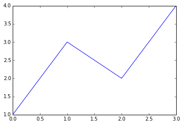

```python
plt.figure()
plt.plot(v)
plt.show()
```

On peut omettre `plt.show()`, lorsque la fonction `plt.ion()` a été appelée ; c'est le cas dans Spyder.

Un peu plus compliqué:

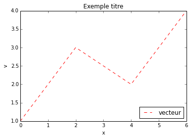

```python
x = np.array([0,2,4,6])
plt.figure()
plt.plot(x, v, 'r--', label='vecteur')
plt.xlabel('x')
plt.ylabel('v')
plt.title('Exemple titre')
plt.legend(loc='lower right')
plt.show()
```

Tableau de dimension 2 (matrice):

```python
# une matrice: l'argument est une liste emboitée
M = np.array([[1, 3], [2, 4]])
print(M)
```

```
[[1 3]
 [2 4]]
```

```python
# accéder à un élément
print(M[0, 0])
print(M[1, 1])
```

```
1
4
```

La variable `M` est aussi du type `ndarray`

```python
print(type(M))
```

```
<type 'numpy.ndarray'>
```

### L'attribut `shape`

`v` et `M` diffèrent par leur taille:

```python
print(v.shape)
```

```
(4,)
```

```python
print(M.shape)
```

```
(2, 2)
```

```python
print(type(M.shape))
```

```
<type 'tuple'>
```

### L'attribut `ndim`

il permet de savoir quel est la dimension d'un ndarray

```python
print(v.ndim)
```

```
1
```

```python
print(M.ndim)
```

```
2
```

### L'attribut `size`

il permet de savoir quel est le nombre d'éléments dans un `ndarray`

```python
print(v.size)
```

```
4
```

```python
print(M.size)
```

```
4
```

### Exemple d'un tableau à 3 dimensions

```python
T = np.array([[[1, 3, 2, 4]]])
print(T)
```

```
[[[1 3 2 4]]]
```

```python
print(T.shape)
```

```
(1, 1, 4)
```

```python
print(T.ndim)
```

```
3
```

```python
print(T.size)
```

```
4
```

```python
np.size(T)
```

```
4
```

Suite au prochain épisode...

## Tableaux NumPy (la suite)

```python
v = np.array([1, 3, 2, 4])
print(v)
```

```
[1 3 2 4]
```

```python
M = np.array([[1, 3], [2, 4]])
print(M)
```

```
[[1 3]
 [2 4]]
```

### L'attribut `dtype`

- Un *ndarray* peut contenir des nombres entiers, flottants, complexes etc.
- On obtient le type des données via l'attribut `dtype`
- `dtype` est l'abréviation de *data type*

```python
print(M)
print(M.dtype)
```

```
[[1 3]
 [2 4]]
int64
```

### Plus d'attributs

```python
M.itemsize # nombre d'octets par élément
```

```
8
```

```python
M.nbytes # nombre d'octets
```

```
32
```

```python
M.nbytes / M.size  # égal à itemsize
```

```
8
```

### Assignation élément par élément

```python
print(M)
```

```
[[1 3]
 [2 4]]
```

```python
M[0,0] = -1
print(M)
```

```
[[-1  3]
 [ 2  4]]
```

Les types doivent être respectés lors d'assignations

```python
M[0,0] = "hello"
```

```
---------------------------------------------------------------------------
ValueError                                Traceback (most recent call last)
<ipython-input-29-a09d72434238> in <module>()
----> 1 M[0,0] = "hello"

ValueError: invalid literal for long() with base 10: 'hello'
```

### Attention !

```python
a = np.array([0, 0, 0])
print(a.dtype)
a[0] = 3.2  # perte de précision
print(a)
```

```
int64
[3 0 0]
```

On peut définir le type de manière explicite en utilisant le mot clé `dtype` en argument:

```python
a = np.array([0, 0, 0], dtype=np.float64)
a[0] = 3.2
print(a)
```

```
[ 3.2  0.   0. ]
```

- Autres options possibles de `dtype` : `int`, `float`, `complex`, `bool`, `object`, etc.
- On peut aussi spécifier la précision en bits: `int32`, `int16`, `float128`, `complex128`, etc.

## Changement de type

```python
M = np.array([[-1, 2], [0, 4]])
print(M.dtype)
```

```
int64
```

```python
M2 = M.astype(float)  # conversion en float
print(M2)
print(M2.dtype)
```

```
[[-1.  2.]
 [ 0.  4.]]
float64
```

```python
M3 = M.astype(bool)  # conversion en bool
print(M3)
print(M3.dtype)
```

```
[[ True  True]
 [False  True]]
bool
```

### Utilisation de fonction de génération d'*arrays*

#### arange "array range"

```python
x = np.array(range(0, 10, 2)) # à partir d'une liste
print(x)
```

```
[0 2 4 6 8]
```

```python
x = np.arange(0, 10, 2) # OK : plus efficace
print(x)
```

```
[0 2 4 6 8]
```

```python
x = np.arange(-1, 1, 0.5)  # avec flottants
print(x)
```

```
[-1.  -0.5  0.   0.5]
```

#### linspace

```python
# avec linspace, le début et la fin SONT inclus
np.linspace(0, 10, 6)
```

```
array([  0.,   2.,   4.,   6.,   8.,  10.])
```

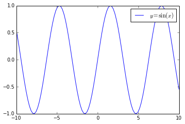

```python
x = np.linspace(-10, 10, 100)
y = np.sin(x)
plt.plot(x, y, label='$y = \sin(x)$')
plt.legend()
plt.show()
```

Suite au prochain épisode...

### Arithmétique sur des tableaux NumPy

```python
a = np.arange(5, dtype=float)
print(a)
```

```
[ 0.  1.  2.  3.  4.]
```

```python
print(a + 1)
```

```
[ 1.  2.  3.  4.  5.]
```

```python
print(2 * a)
```

```
[ 0.  2.  4.  6.  8.]
```

```python
print(a ** 2)
```

```
[  0.   1.   4.   9.  16.]
```

### Arithmétique sur des tableaux NumPy (suite)

```python
a = np.arange(5, dtype=float)
print(a)
```

```
[ 0.  1.  2.  3.  4.]
```

```python
print(a + a)  # addition élément par élément
```

```
[ 0.  2.  4.  6.  8.]
```

```python
print(a * a)  # multiplication élément par élément
```

```
[  0.   1.   4.   9.  16.]
```

### Le problème de la division entière

```python
a = np.array([1, 2], dtype=np.int64)
b = np.array([2, 2], dtype=np.int64)
print(a / b)
```

```
[0 1]
```

```python
a = np.array([1, 2], dtype=float)
b = np.array([2, 2], dtype=float)
print(a / b)
print(a // b)
```

```
[ 0.5  1. ]
[ 0.  1.]
```

### Données aléatoires

```python
from numpy import random
```

```python
# tirage uniforme dans [0,1]
random.random_sample((3, 3))  # ou random.rand
```

```
array([[ 0.39901777,  0.6412892 ,  0.97677018],
       [ 0.88608808,  0.2866462 ,  0.19678252],
       [ 0.84092386,  0.39505946,  0.78899804]])
```

```python
# tirage suivant une loi normale standard
random.standard_normal((3, 3))  # ou random.randn
```

```
array([[ 0.08910219, -0.76917745, -1.59923397],
       [-0.31889444, -0.04475295, -1.17248134],
       [ 0.88410981, -1.10103646,  1.45595075]])
```

Affichage de l'histogramme des tirages

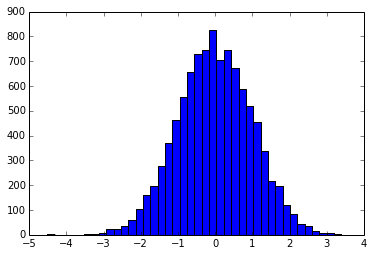

```python
a = random.standard_normal(10000)
hh = plt.hist(a, 40)
```

Affichage des tirages comme une image

```python
C = random.standard_normal((32, 32))
print(C.shape)
```

```
(32, 32)
```

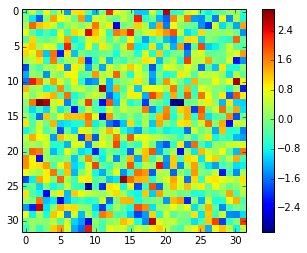

```python
plt.imshow(C, interpolation='nearest')
plt.colorbar()
plt.show()
```

#### zeros et ones

```python
# Création d'un tableau 2D de zeros
A = np.zeros((2, 3)) # Attention: zeros(2, 3) est FAUX
print(A)
print(A.dtype)
```

```
[[ 0.  0.  0.]
 [ 0.  0.  0.]]
float64
```

```python
print(np.zeros((1, 3), dtype=int))  # ligne
```

```
[[0 0 0]]
```

```python
print(np.zeros((3, 1), dtype=int))  # colonne
```

```
[[0]
 [0]
 [0]]
```

```python
print(np.ones((3, 3)))  # tableau 3x3 de 1
```

```
[[ 1.  1.  1.]
 [ 1.  1.  1.]
 [ 1.  1.  1.]]
```

#### diag

```python
# création d'une matrice diagonale
D = np.diag([1, 2, 3])
print(D)
```

```
[[1 0 0]
 [0 2 0]
 [0 0 3]]
```

```python
# extraction de la diagonale
print(np.diag(D))
```

```
[1 2 3]
```

Suite au prochain épisode...